# Predicting farmers profits in rural Kenya

Giuliana Daga

12/11/2020

## Introduction

This report analyzes spatial aggregation and potential sources of improvement of Bima Pima, an index-based microinsurance product offered in Siaya County, Kenya. The product is piloted in Kenya by Agriculture and Climate Risk Enterprise Ltd. (ACRE), operating in Kenya since 2009 and now works in over ten countries across Africa and South Asia. An index-based product differs from more conventional insurance in that it links payouts, not to actual crop losses but exogenous events. In this case, ACRE takes measured rainfall, which likely correlates with such losses. This way of assessing risk allows for rapid payouts, eliminates the need for expensive crop evaluations, and eliminates moral hazard, given that farmers have an incentive to make their farms succeed. However, basis risk remains an issue, given that the correlation between insurable events and yields is imperfect, especially at the low end of the yield distribution.

The purpose of this report is twofold. First, transform statistical analysis into a geospatial one with useful visualizations that improve our understanding of the context. We will use survey data to map farmers at the center of their farms. We will overlay this data with the Kenya counties’ shapefile and a self-built fishnet based on ACRE’s payout calculations. Second, we will use machine learning methods to explore which other weather best predicts farmers’ self-reported profits in the Short Rains season 2018-2019. We will succeed if we learn whether adding different weather variables improves our understanding of farmers’ performance to protect smallholder farmers facing considerable risks.

## Problem Statement and Background

Smallholder farmers are increasingly affected by weather forces beyond their control, affecting their yields, profits, and livelihoods significantly. However, less than 20 percent globally have insurance coverage to protect themselves (GSMA, 2020). Higher crop yield variability may increase poverty and food insecurity, especially in developing countries (Wheeler, 2013; Bown, 2015). After catastrophic weather events, smallholder households may end up selling assets to smooth consumption (Carter, 2006).

On the demand side, low awareness and willingness to pay, together with liquidity constraints, lousy perception of the product (a lack of trust in the business), and behavioral biases such as present preferences (farmers prefer payouts closet to the current time). On the supply side, insurance providers have historically overlooked the market, given that the higher cost of serving rural customers makes it a less profitable segment of the industry.

Weather index insurance (WII) could potentially overcome some of the problems with traditional insurance schemes. Through this method, insurance providers calculate payouts subject to objectively measured weather data, which presumably correlates with production losses. Compared with conventional insurance products, WII imply fewer administration costs, making them more affordable and giving faster payments to farmers (Sibiko, Veettil, & Qaim, 2018).

However, despite all these advantages, smallholder farmers haven’t voluntary uptake the product as anticipated. Some authors think that adding to the previously mentioned challenges for farmers (liquidity constraints, preference biases, etc.), the basis risk that often remains is a significant issue (Norton, Turvey, Osgood, 2012). Flawed basis risk means that the construction of the index insurance may not match the insured’s risk exposure. Index insurance services have been in the industry for over the last ten years, using mobile technology to digitize farmer’s registration, premiums, payout claims, and satellite technologies to assess service delivery. This report will explore the basis risk’s local dimension, looking for satellite weather data that best describes the index/ yield relationship for the Short rains season 2018 in Siaya County, Kenya.

## Data

The data in this project is composed using three main data sources:

- Georgetown Initiative on Innovation, Development, and Evaluation (Gui2de) - Household survey data provides a measure of, among other things, maize’s harvest and farmer profits on Baseline (before first planting season, Jul-Aug 2018), Midline (at the end of the first planting season, Feb-Mar 2019), and Endline (at the end of the second planting season, Nov-Dec 2019). For this analysis, we will focus on the first season; therefore, we will use Midline.
- IRI/LDEO Climate Data Library is a library of datasets. We will use the NOAA NCEP CPC CAMS, with daily precipitation data measured in milliliters for each pixel. There is availability from 1983 up to date. However, we will only use it from September 2018 to January 2019.
- NASA Giovanni (Geospatial Interactive Online Visualization ANd aNalysis Infrastructure) data collection: obtained daily data such as atmospheric pressure, atmospheric temperature, surface thermal properties, soil temperature, wind speed, radiation, etc.

## Methodology

### 1. Where are our farmers?

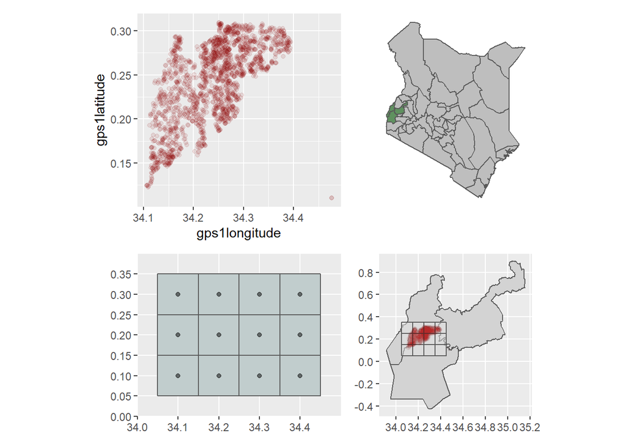

### 2. Geospatial analysis: Survey data

#### 1. Total profits and investment at the pixel level

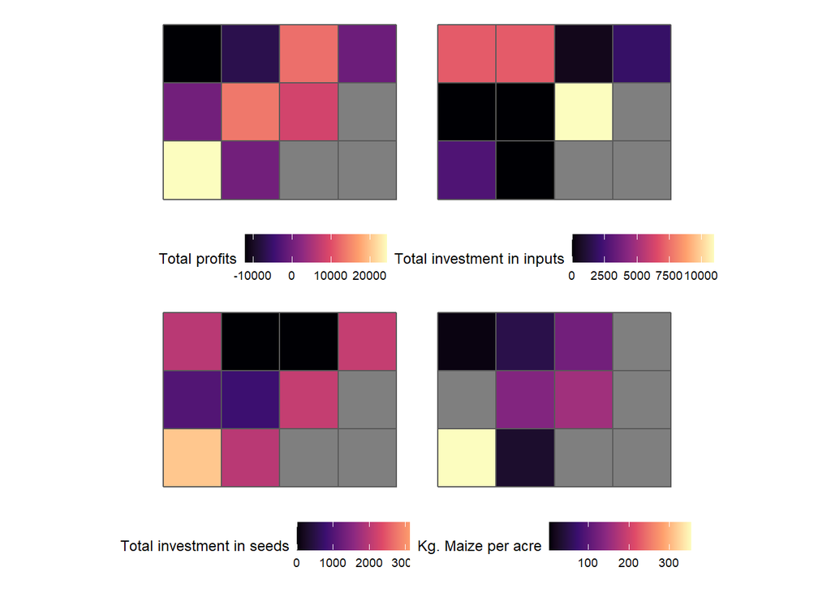

### 3. Weather data sources:

#### 1. Columbia rainfall data

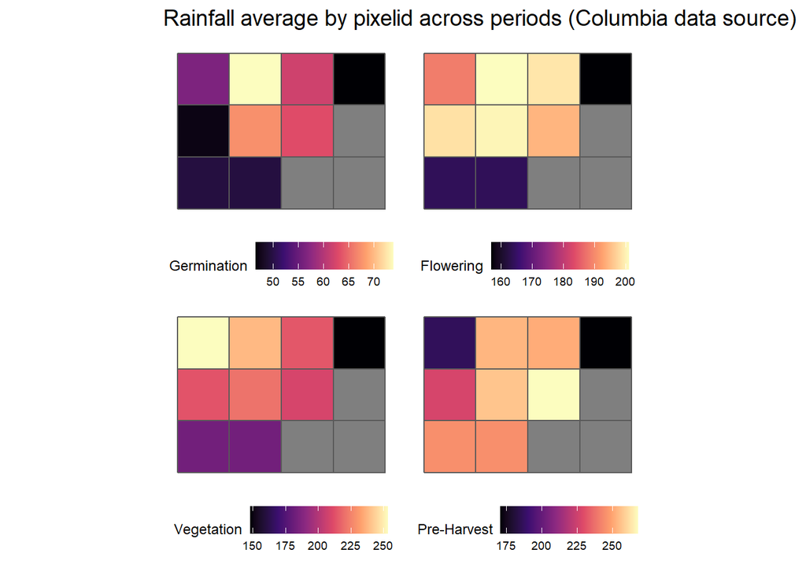

#### 2. Giovanni NASA

[figure not shown]